სმკმ: მეცხრე შეხვედრა

# სოციალურ მეცნიერებათა კვლევის მეთოდები

დავით სიჭინავა  
30 აპრილი, 2020 წ.

მეცხრე შეხვედრა

### დღევანდელი შეხვედრის გეგმა

- ლექცია: მასობრივი გამოკითხვა
- სემინარი

### რა არის მასობრივი გამოკითხვა?

> ადამიანების მასობრივი ფორმით ანკეტირება სტრუქტურირებული კითხვარის მეშვეობით, რათა წარმოდგენა შევიქმნათ ამა თუ იმ სოციალური ფენომენის გავრცელების და მისი თავისებურებების შესახებ

### რა არის მასობრივი გამოკითხვა?

- მეცნიერული მეთოდია
  - პრობლემის ჩამოყალიბება
  - ჰიპოთეზის ფორმირება
  - კვლევის დიზაინის მომზადება
  - შერჩევა
  - კვლევის ინსტრუმენტი (კითხვარი)
  - მონაცემთა მოგროვება
  - მონაცემთა ანალიზი
  - ანგარიშის მომზადება

### ვინ იყენებს მასობრივ გამოკითხვას?

> თქვენი აზრით, რა შეიძლება ჩაითვალოს ყველაზე მასშტაბურ მასობრივ გამოკითხვად?

### ვინ იყენებს მასობრივ გამოკითხვას?

[figure not shown]

### ვინ იყენებს მასობრივ გამოკითხვას?

- სოციოლოგები, ფსიქოლოგები, ეკონომისტები, გეოგრაფები, ეპიდემიოლოგები, საზოგადოებრივი ჯანდაცვის სპეციალისტები, პოლიტოლოგები…
- *ჟურნალისტები* და კომუნიკაციის სპეციალისტები
- სახელმწიფო დაწესებულებები

### მასობრივი გამოკითხვა

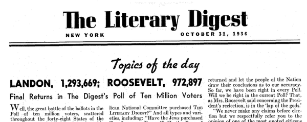

### Literary digest-ის 1936 წლის გამოკითხვა

- N=2.4 მლნ.
- ავტომობილების სარეგისტრაციო სიები
- სატელეფონო ცნობარები
- ჟურნალის ხელმომწერები

### Literary digest-ის 1936 წლის გამოკითხვა

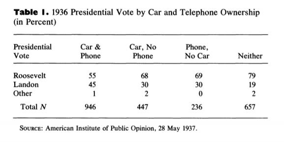

### მასობრივი გამოკითხვა

[figure not shown]

### მასობრივი გამოკითხვა

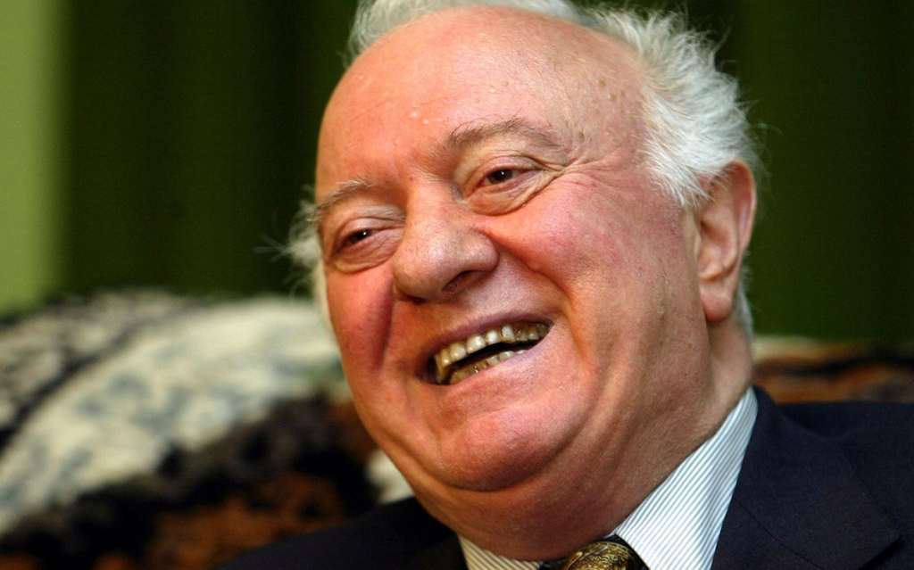

### მასობრივი გამოკითხვა

> იმავ საღამოს ანკეტა გადავათვალიერე, ყოველი შეკითხვა გასაგები, მარტივი და ამასთანავე საინტერესო იყო - მე მიყვარს ჩემი დარგი. უფრო სწორად, მომწონს - შეკითხვების დასმა უცნობი ადამიანებისათვის, ახალი გუნება-განწყობანი, ხანდახან ფარული ჰუმორი, მაგრამ, რაც მთავარია, ენერგია, ენერგია, მიზანდასახულობა, ყველაფერია ერთად.

*დოჩანაშვილი, 1973 წ.*

### მასობრივი გამოკითხვა

[figure not shown]

### მასობრივი გამოკითხვის ფორმები

- ინტერვიუ
  - პირისპირი (face-to-face) გამოკითხვა
  - სატელეფონო გამოკითხვა
- თვითადმინისტრირებადი ანკეტირება

### პირისპირი გამოკითხვა

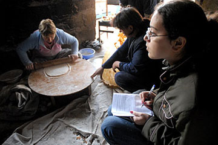

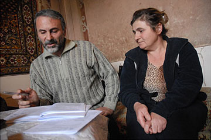

### პირისპირი გამოკითხვა

- PAPI
- CAPI

### პირისპირი გამოკითხვა

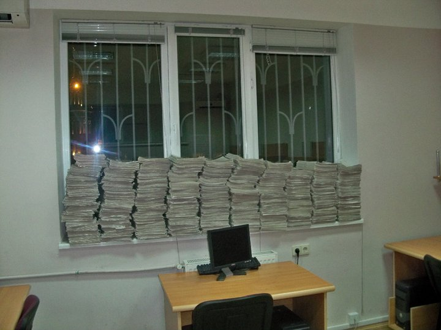

[figure not shown]

### სატელეფონო გამოკითხვა

- ავტომატიზებული სატელეფონო გამოკითხვა
- შემთხვევითი ნომრების გენერირების მეთოდი
- სატელეფონო წიგნები

### ვებ-გამოკითხვა

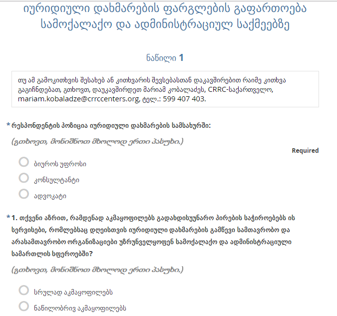

### ვებ-გამოკითხვა

- SurveyMonkey
- Google Forms
- ODK Survey
- …

### გამოკითხვის მეთოდების შედარება

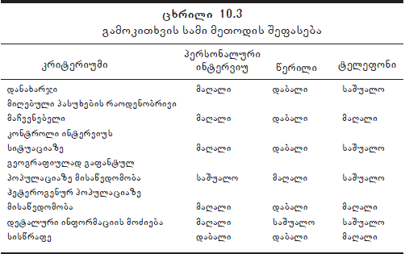

### პირისპირ ინტერვიუ

[figure not shown]

- მოქნილობა
- სიტუაციის კონტროლი
- სრული ინფორმაცია
- პასუხების მიღების მაღალი მაჩვენებელი

[figure not shown]

- მაღალი დანახარჯი
- მიკერძოებულობა
- ანონიმურობის სიმცირე

### სატელეფონო ინტერვიუ

[figure not shown]

- დანახარჯი
- სისწრაფე
- მაღალი გამოპასუხება
- ხარისხი

[figure not shown]

- სენსიტიური თემები
- შეწყვეტილი ინტერვიუები
- ნაკლები ინფორმაცია

### კვლევის დიზაინები

- დროის ერთი კონკრეტული მონაკვეთი (cross-sectional)
- დროის მწკრივები

### დროის მწკრივები

- ტენდენციის კვლევა
- კოჰორტული კვლევა
- პანელური კვლევა